# Analyzing resting-state EEG and Spelling Performance in Young Adults

Leandro Ledesma

2024-03-13

### Universal block code settings

```r
knitr::opts_chunk$set(echo = FALSE)
knitr::opts_chunk$set(message = FALSE)
knitr::opts_chunk$set(comment = NULL)
knitr::opts_chunk$set(warning = FALSE)
```

### Load in the data manipulation packages first

### Load in our predictor variable

### Load in our dependent variable

### Combine the dataset into one

### Index subjects by those that met the requirements

- No self-report injury
- No Epilepsy
- Removing missing data
- No one below ‘IQ’ of 70 (more than 2 SD below the mean)
- Extremely poor spellers (more than 3 SD below the mean)
- Issues with EEG recordings
- Did not survive EEG cleaning

### Missing data

- All data should be present based on the index from the previous section

This is an automated response: The current dataset has the dimensions 1796 x 17 . Below is a frequency table showing the number of missing data for each variable.

[output not shown]

This is an automated response: Our final sample size is n= 449

## Descriptive statistics of the data

We can use the describe() function from the psych package to give us descriptive statistics from the variables that will be incorporated into the model. We will create 3 tables. The first will contain information about the continuous predictors. The next will have the frequency of the categorical variables. Lastly we will have a table for the resting-state EEG frequency bands.

### Continuous predictors

Table 1: Descriptive Statistics of Continuous Predictors

|  | Mean | Median | SD | Min | Max | Range | n |
| --- | --- | --- | --- | --- | --- | --- | --- |
| Spelling Error | 13.38 | 12 | 8.62 | 0 | 41 | 41 | 449 |
| Age | 20.27 | 19 | 4.44 | 15 | 36 | 21 | 449 |
| CFIT Raw Scores | 30.87 | 32 | 5.37 | 18 | 42 | 24 | 449 |

### Categorical predictors

Table 2: Descriptive Statistics of Categorical Variables.

| Female | Male | Male (%) | Bio F. | Insti. | Bio F. (%) | N |
| --- | --- | --- | --- | --- | --- | --- |
| 256 | 193 | 43 | 246 | 203 | 55 | 449 |

Table 2: Descriptive Statistics of Categorical Variables.

|  | Female | Male | Total |
| --- | --- | --- | --- |
| Bio F. | 153 | 93 | 246 |
| Insti. | 103 | 100 | 203 |
| Total | 256 | 193 | 449 |

### Descriptive statistics of the EEG data

- Right now this is for eyes-closed only

Table 3: Descriptive Statistics of Power from each Frequency Band (Frontal)

| Frequency Band | Mean | Median | SD | Min | Max | Range | n |
| --- | --- | --- | --- | --- | --- | --- | --- |
| Delta (0.5-3.75Hz) | 2.48 | 1.97 | 1.67 | 0.49 | 13.18 | 12.69 | 449 |
| Theta (4-7.75Hz) | 0.49 | 0.38 | 0.36 | 0.11 | 3.32 | 3.20 | 449 |
| Alpha (8-12Hz) | 1.11 | 0.81 | 1.04 | 0.07 | 8.85 | 8.78 | 449 |
| Beta (12-30Hz) | 0.10 | 0.08 | 0.07 | 0.03 | 0.88 | 0.85 | 449 |

Table 3: Descriptive Statistics of Power from each Frequency Band (Temporal)

| Frequency Band | Mean | Median | SD | Min | Max | Range | n |
| --- | --- | --- | --- | --- | --- | --- | --- |
| Delta (0.5-3.75Hz) | 1.46 | 1.26 | 0.77 | 0.34 | 6.08 | 5.75 | 449 |
| Theta (4-7.75Hz) | 0.51 | 0.37 | 0.43 | 0.10 | 3.57 | 3.47 | 449 |
| Alpha (8-12Hz) | 0.90 | 0.74 | 0.65 | 0.07 | 3.48 | 3.42 | 449 |
| Beta (12-30Hz) | 0.15 | 0.12 | 0.11 | 0.02 | 0.99 | 0.97 | 449 |

Table 3: Descriptive Statistics of Power from each Frequency Band (Parietal)

| Frequency Band | Mean | Median | SD | Min | Max | Range | n |
| --- | --- | --- | --- | --- | --- | --- | --- |
| Delta (0.5-3.75Hz) | 1.14 | 0.97 | 0.69 | 0.32 | 5.94 | 5.62 | 449 |
| Theta (4-7.75Hz) | 0.48 | 0.32 | 0.49 | 0.07 | 3.96 | 3.89 | 449 |
| Alpha (8-12Hz) | 1.71 | 1.19 | 1.68 | 0.05 | 12.34 | 12.28 | 449 |
| Beta (12-30Hz) | 0.10 | 0.08 | 0.06 | 0.01 | 0.35 | 0.34 | 449 |

Table 3: Descriptive Statistics of Power from each Frequency Band (Occipital)

| Frequency Band | Mean | Median | SD | Min | Max | Range | n |
| --- | --- | --- | --- | --- | --- | --- | --- |
| Delta (0.5-3.75Hz) | 2.12 | 1.71 | 1.45 | 0.39 | 14.37 | 13.97 | 449 |
| Theta (4-7.75Hz) | 0.86 | 0.60 | 0.82 | 0.12 | 6.89 | 6.77 | 449 |
| Alpha (8-12Hz) | 4.31 | 3.04 | 4.44 | 0.07 | 35.74 | 35.67 | 449 |
| Beta (12-30Hz) | 0.21 | 0.18 | 0.15 | 0.04 | 1.63 | 1.59 | 449 |

### Visualizing all continuous variables as histograms

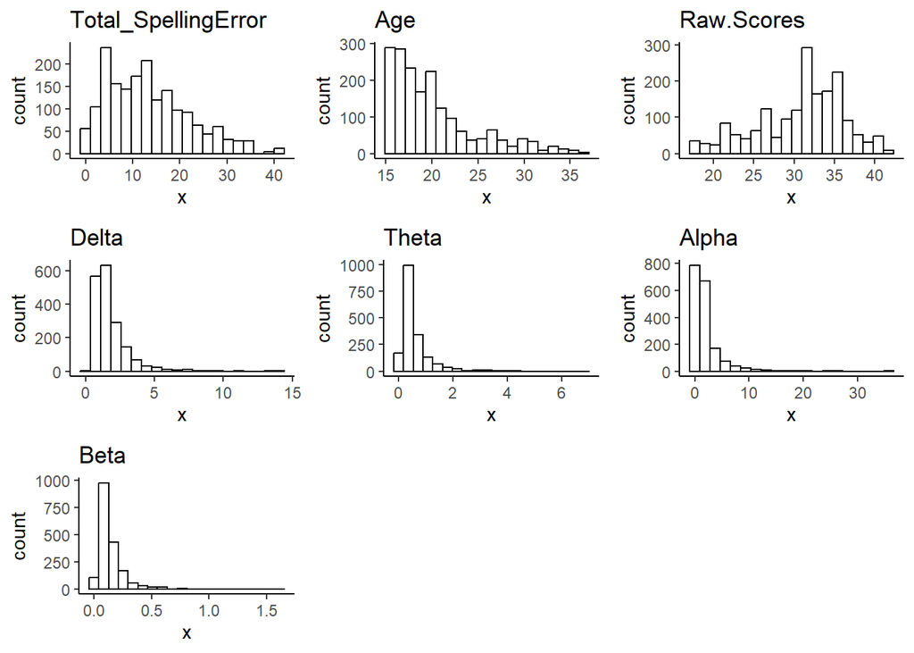

- The Frequency Bands (Outcome Measures) do not look parametric. However, we will continue to use parametric tests and identify if the errors look normally distributed.

### Run a correlation matrix for each frequency band

|  | Delta | Total_SpellingError | Age | Raw.Scores |
| --- | --- | --- | --- | --- |
| Delta | 1.000 | 0.012 | 0.002 | -0.001 |
| Total_SpellingError | 0.012 | 1.000 | -0.209*** | -0.612*** |
| Age | 0.002 | -0.209*** | 1.000 | 0.097*** |
| Raw.Scores | -0.001 | -0.612*** | 0.097*** | 1.000 |

Note:  
*** indicates p <.001  
** indicates p <.01  
* indicates p <.05

|  | Theta | Total_SpellingError | Age | Raw.Scores |
| --- | --- | --- | --- | --- |
| Theta | 1.000 | 0.014 | -0.011 | 0.005 |
| Total_SpellingError | 0.014 | 1.000 | -0.209*** | -0.612*** |
| Age | -0.011 | -0.209*** | 1.000 | 0.097*** |
| Raw.Scores | 0.005 | -0.612*** | 0.097*** | 1.000 |

Note:  
*** indicates p <.001  
** indicates p <.01  
* indicates p <.05

|  | Alpha | Total_SpellingError | Age | Raw.Scores |
| --- | --- | --- | --- | --- |
| Alpha | 1.000 | 0.003 | -0.028 | 0.027 |
| Total_SpellingError | 0.003 | 1.000 | -0.209*** | -0.612*** |
| Age | -0.028 | -0.209*** | 1.000 | 0.097*** |
| Raw.Scores | 0.027 | -0.612*** | 0.097*** | 1.000 |

Note:  
*** indicates p <.001  
** indicates p <.01  
* indicates p <.05

|  | Beta | Total_SpellingError | Age | Raw.Scores |
| --- | --- | --- | --- | --- |
| Beta | 1.000 | -0.000 | 0.046 | 0.013 |
| Total_SpellingError | -0.000 | 1.000 | -0.209*** | -0.612*** |
| Age | 0.046 | -0.209*** | 1.000 | 0.097*** |
| Raw.Scores | 0.013 | -0.612*** | 0.097*** | 1.000 |

Note:  
*** indicates p <.001  
** indicates p <.01  
* indicates p <.05

### Visualizing scatterplots

for predictors and frequency bands only

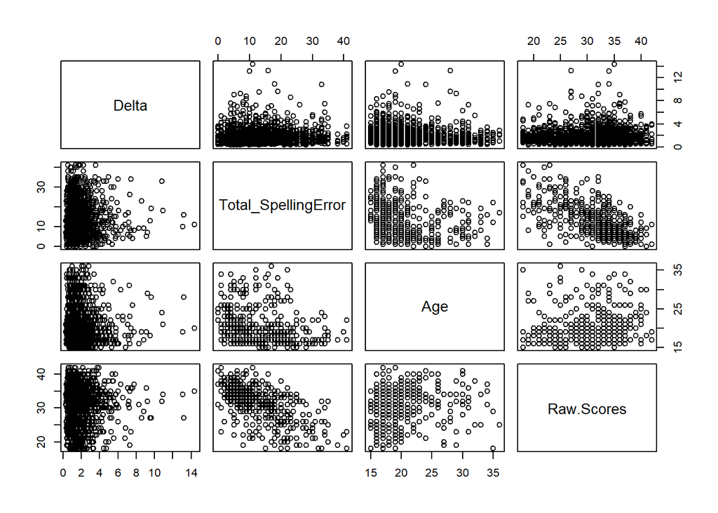

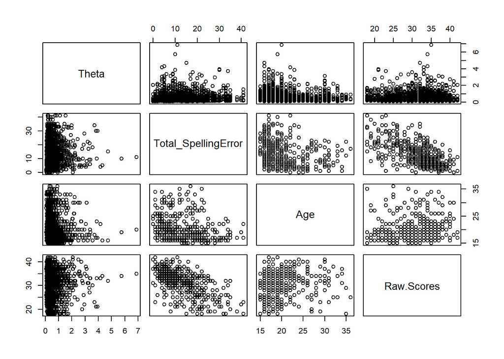

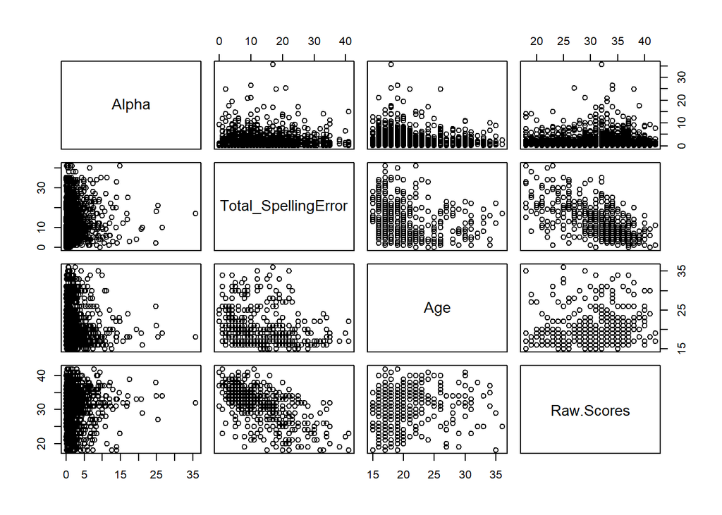

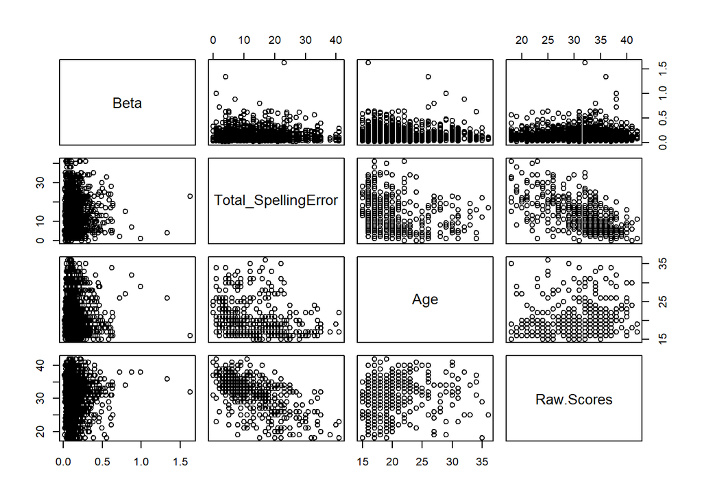

### Check for independence between categorical variables

P-value is significant. It seems there are more females who were raised in biological families than males. This may not be as big of a deal as initially thought.

```
     Group
Sex    BF  IC Sum
  F   153 103 256
  M    93 100 193
  Sum 246 203 449
```

```
   Group
Sex    BF    IC
  F 0.341 0.229
  M 0.207 0.223
```

```
    Pearson's Chi-squared test with Yates' continuity correction

data:  contingency.table
X-squared = 5.4978, df = 1, p-value = 0.01904
```

### Run a multiple regression predicting the power of each frequency band

### Make the multiple regression look prettier

| Model | Beta | Std. Error | t | Sig. | Std Beta | Tolerance | VIF |
| --- | --- | --- | --- | --- | --- | --- | --- |
| (Intercept) | 3.61 | 0.33 | 11.09 | 0.00*** | NA | NA | NA |
| Spelling Error | 0.01 | 0.01 | 1.45 | 0.15 | 0.05 | 0.47 | 2.13 |
| Age | -0.06 | 0.01 | -7.80 | 0.00*** | -0.19 | 0.92 | 1.09 |
| Raw CFIT Score | -0.02 | 0.01 | -3.12 | 0.00*** | -0.09 | 0.58 | 1.73 |
| Male | -0.09 | 0.06 | -1.35 | 0.18 | -0.03 | 0.90 | 1.11 |
| IC | -0.03 | 0.08 | -0.43 | 0.67 | -0.01 | 0.59 | 1.69 |

*** indicates p <.001; ** indicates p <.01; * indicates p <.05  
Residual standard error: 0.112 , on 1790 degrees of freedom  
Multiple R-squared: 0.0163 , Adjusted R-squared: 0.01359  
F-statistic: 5.95 on 5 and 1790 DF, p-value: 1.83690460557488e-05

| Model | Beta | Std. Error | t | Sig. | Std Beta | Tolerance | VIF |
| --- | --- | --- | --- | --- | --- | --- | --- |
| (Intercept) | 0.68 | 0.14 | 4.82 | 0.00*** | NA | NA | NA |
| Spelling Error | 0.00 | 0.00 | -0.26 | 0.79 | -0.01 | 0.47 | 2.13 |
| Age | -0.02 | 0.00 | -5.35 | 0.00*** | -0.13 | 0.92 | 1.09 |
| Raw CFIT Score | 0.01 | 0.00 | 2.01 | 0.04* | 0.06 | 0.58 | 1.73 |
| Male | -0.04 | 0.03 | -1.36 | 0.17 | -0.03 | 0.90 | 1.11 |
| IC | 0.14 | 0.03 | 3.95 | 0.00*** | 0.12 | 0.59 | 1.69 |

*** indicates p <.001; ** indicates p <.01; * indicates p <.05  
Residual standard error: 0.112 , on 1790 degrees of freedom  
Multiple R-squared: 0.0163 , Adjusted R-squared: 0.01359  
F-statistic: 5.95 on 5 and 1790 DF, p-value: 1.83690460557488e-05

| Model | Beta | Std. Error | t | Sig. | Std Beta | Tolerance | VIF |
| --- | --- | --- | --- | --- | --- | --- | --- |
| (Intercept) | 2.33 | 0.70 | 3.31 | 0.00*** | NA | NA | NA |
| Spelling Error | -0.02 | 0.01 | -1.67 | 0.1 | -0.06 | 0.47 | 2.13 |
| Age | -0.04 | 0.02 | -2.73 | 0.01* | -0.07 | 0.92 | 1.09 |
| Raw CFIT Score | 0.02 | 0.02 | 1.24 | 0.21 | 0.04 | 0.58 | 1.73 |
| Male | 0.03 | 0.14 | 0.19 | 0.85 | 0.00 | 0.90 | 1.11 |
| IC | 0.35 | 0.17 | 2.05 | 0.04* | 0.06 | 0.59 | 1.69 |

*** indicates p <.001; ** indicates p <.01; * indicates p <.05  
Residual standard error: 0.112 , on 1790 degrees of freedom  
Multiple R-squared: 0.0163 , Adjusted R-squared: 0.01359  
F-statistic: 5.95 on 5 and 1790 DF, p-value: 1.83690460557488e-05

| Model | Beta | Std. Error | t | Sig. | Std Beta | Tolerance | VIF |
| --- | --- | --- | --- | --- | --- | --- | --- |
| (Intercept) | 0.17 | 0.03 | 6.06 | 0.00*** | NA | NA | NA |
| Spelling Error | 0.00 | 0.00 | 0.60 | 0.55 | 0.02 | 0.47 | 2.13 |
| Age | 0.00 | 0.00 | -2.28 | 0.02* | -0.06 | 0.92 | 1.09 |
| Raw CFIT Score | 0.00 | 0.00 | 0.14 | 0.89 | 0.00 | 0.58 | 1.73 |
| Male | -0.03 | 0.01 | -4.57 | 0.00*** | -0.11 | 0.90 | 1.11 |
| IC | 0.00 | 0.01 | 0.62 | 0.53 | 0.02 | 0.59 | 1.69 |

*** indicates p <.001; ** indicates p <.01; * indicates p <.05  
Residual standard error: 0.112 , on 1790 degrees of freedom  
Multiple R-squared: 0.0163 , Adjusted R-squared: 0.01359  
F-statistic: 5.95 on 5 and 1790 DF, p-value: 1.83690460557488e-05

### Run a multiple regression predicting the power of each frequency band with an interaction

### Make the multiple regression look prettier

| Model | Beta | Std. Error | t | Sig. | Std Beta | Tolerance | VIF |
| --- | --- | --- | --- | --- | --- | --- | --- |
| (Intercept) | 3.14 | 0.41 | 7.75 | 0.00*** | NA | NA | NA |
| Spelling Error | 0.04 | 0.02 | 2.25 | 0.02* | 0.28 | 0.03 | 29.64 |
| Age | -0.03 | 0.01 | -2.48 | 0.01* | -0.11 | 0.26 | 3.91 |
| Raw CFIT Score | -0.02 | 0.01 | -3.07 | 0.00*** | -0.09 | 0.58 | 1.73 |
| Male | -0.10 | 0.07 | -1.47 | 0.14 | -0.04 | 0.90 | 1.12 |
| IC | -0.03 | 0.08 | -0.37 | 0.71 | -0.01 | 0.59 | 1.69 |
| Spelling Error x Age | 0.00 | 0.00 | -1.93 | 0.05 | -0.01 | 0.04 | 27.44 |

*** indicates p <.001; ** indicates p <.01; * indicates p <.05  
Residual standard error: 0.1117 , on 1789 degrees of freedom  
Multiple R-squared: 0.0235 , Adjusted R-squared: 0.02027  
F-statistic: 7.19 on 6 and 1789 DF, p-value: 1.34961242333374e-07

| Model | Beta | Std. Error | t | Sig. | Std Beta | Tolerance | VIF |
| --- | --- | --- | --- | --- | --- | --- | --- |
| (Intercept) | 0.52 | 0.18 | 2.96 | 0.00*** | NA | NA | NA |
| Spelling Error | 0.01 | 0.01 | 1.40 | 0.16 | 0.18 | 0.03 | 29.64 |
| Age | -0.01 | 0.01 | -1.53 | 0.13 | -0.07 | 0.26 | 3.91 |
| Raw CFIT Score | 0.01 | 0.00 | 2.06 | 0.04* | 0.06 | 0.58 | 1.73 |
| Male | -0.04 | 0.03 | -1.45 | 0.15 | -0.04 | 0.90 | 1.12 |
| IC | 0.14 | 0.03 | 4.00 | 0.00*** | 0.12 | 0.59 | 1.69 |
| Spelling Error x Age | 0.00 | 0.00 | -1.52 | 0.13 | -0.01 | 0.04 | 27.44 |

*** indicates p <.001; ** indicates p <.01; * indicates p <.05  
Residual standard error: 0.1117 , on 1789 degrees of freedom  
Multiple R-squared: 0.0235 , Adjusted R-squared: 0.02027  
F-statistic: 7.19 on 6 and 1789 DF, p-value: 1.34961242333374e-07

| Model | Beta | Std. Error | t | Sig. | Std Beta | Tolerance | VIF |
| --- | --- | --- | --- | --- | --- | --- | --- |
| (Intercept) | 1.55 | 0.88 | 1.77 | 0.08 | NA | NA | NA |
| Spelling Error | 0.04 | 0.04 | 0.98 | 0.32 | 0.13 | 0.03 | 29.64 |
| Age | -0.01 | 0.03 | -0.18 | 0.86 | -0.01 | 0.26 | 3.91 |
| Raw CFIT Score | 0.02 | 0.02 | 1.28 | 0.2 | 0.04 | 0.58 | 1.73 |
| Male | 0.01 | 0.14 | 0.10 | 0.92 | 0.00 | 0.90 | 1.12 |
| IC | 0.36 | 0.17 | 2.10 | 0.04* | 0.06 | 0.59 | 1.69 |
| Spelling Error x Age | 0.00 | 0.00 | -1.49 | 0.14 | -0.01 | 0.04 | 27.44 |

*** indicates p <.001; ** indicates p <.01; * indicates p <.05  
Residual standard error: 0.1117 , on 1789 degrees of freedom  
Multiple R-squared: 0.0235 , Adjusted R-squared: 0.02027  
F-statistic: 7.19 on 6 and 1789 DF, p-value: 1.34961242333374e-07

| Model | Beta | Std. Error | t | Sig. | Std Beta | Tolerance | VIF |
| --- | --- | --- | --- | --- | --- | --- | --- |
| (Intercept) | 0.10 | 0.04 | 2.71 | 0.01* | NA | NA | NA |
| Spelling Error | 0.01 | 0.00 | 3.66 | 0.00*** | 0.47 | 0.03 | 29.64 |
| Age | 0.00 | 0.00 | 1.88 | 0.06 | 0.09 | 0.26 | 3.91 |
| Raw CFIT Score | 0.00 | 0.00 | 0.24 | 0.81 | 0.01 | 0.58 | 1.73 |
| Male | -0.03 | 0.01 | -4.79 | 0.00*** | -0.12 | 0.90 | 1.12 |
| IC | 0.01 | 0.01 | 0.73 | 0.46 | 0.02 | 0.59 | 1.69 |
| Spelling Error x Age | 0.00 | 0.00 | -3.63 | 0.00*** | -0.02 | 0.04 | 27.44 |

*** indicates p <.001; ** indicates p <.01; * indicates p <.05  
Residual standard error: 0.1117 , on 1789 degrees of freedom  
Multiple R-squared: 0.0235 , Adjusted R-squared: 0.02027  
F-statistic: 7.19 on 6 and 1789 DF, p-value: 1.34961242333374e-07

### Explicitly centering variables

|  | vars | n | mean | sd | median | trimmed | mad | min | max | range | skew | kurtosis | se |
| --- | --- | --- | --- | --- | --- | --- | --- | --- | --- | --- | --- | --- | --- |
| ID | 1 | 1796 | 55103.45 | 25791.90 | 56234.00 | 55153.62 | 31678.71 | 10053.00 | 99982.00 | 89929.00 | -0.04 | -1.16 | 608.60 |
| Sex* | 2 | 1796 | 1.43 | 0.50 | 1.00 | 1.41 | 0.00 | 1.00 | 2.00 | 1.00 | 0.28 | -1.92 | 0.01 |
| Age | 3 | 1796 | 20.27 | 4.43 | 19.00 | 19.54 | 2.97 | 15.00 | 36.00 | 21.00 | 1.38 | 1.36 | 0.10 |
| Group* | 4 | 1796 | 1.45 | 0.50 | 1.00 | 1.44 | 0.00 | 1.00 | 2.00 | 1.00 | 0.19 | -1.96 | 0.01 |
| Raw.Scores | 5 | 1796 | 30.87 | 5.37 | 32.00 | 31.21 | 4.45 | 18.00 | 42.00 | 24.00 | -0.54 | -0.31 | 0.13 |
| Total_SpellingError | 6 | 1796 | 13.38 | 8.61 | 12.00 | 12.59 | 8.90 | 0.00 | 41.00 | 41.00 | 0.74 | 0.00 | 0.20 |
| Condition* | 7 | 1796 | 1.00 | 0.00 | 1.00 | 1.00 | 0.00 | 1.00 | 1.00 | 0.00 | NaN | NaN | 0.00 |
| Topography* | 8 | 1796 | 2.50 | 1.12 | 2.50 | 2.50 | 1.48 | 1.00 | 4.00 | 3.00 | 0.00 | -1.36 | 0.03 |
| Delta | 9 | 1796 | 1.80 | 1.33 | 1.47 | 1.58 | 0.79 | 0.32 | 14.37 | 14.05 | 3.21 | 17.13 | 0.03 |
| Theta | 10 | 1796 | 0.58 | 0.57 | 0.40 | 0.47 | 0.27 | 0.07 | 6.89 | 6.82 | 3.56 | 20.37 | 0.01 |
| Alpha | 11 | 1796 | 2.01 | 2.80 | 1.10 | 1.42 | 1.02 | 0.05 | 35.74 | 35.69 | 4.32 | 28.88 | 0.07 |
| Beta | 12 | 1796 | 0.14 | 0.11 | 0.11 | 0.12 | 0.07 | 0.01 | 1.63 | 1.61 | 3.79 | 29.40 | 0.00 |
| Delta.z | 13 | 1796 | -0.02 | 0.97 | -0.28 | -0.18 | 0.61 | -1.41 | 8.39 | 9.79 | 2.66 | 11.78 | 0.02 |
| Theta.z | 14 | 1796 | 0.02 | 1.01 | -0.31 | -0.18 | 0.53 | -1.04 | 7.88 | 8.92 | 2.92 | 12.35 | 0.02 |
| Alpha.z | 15 | 1796 | 0.02 | 1.00 | -0.27 | -0.14 | 0.68 | -1.25 | 7.52 | 8.78 | 2.25 | 7.96 | 0.02 |
| Beta.z | 16 | 1796 | 0.01 | 0.99 | -0.24 | -0.14 | 0.64 | -1.32 | 11.53 | 12.85 | 3.29 | 22.01 | 0.02 |
| Exclusion* | 17 | 1796 | 1.06 | 0.23 | 1.00 | 1.00 | 0.00 | 1.00 | 2.00 | 1.00 | 3.87 | 13.00 | 0.01 |
| Male | 18 | 1796 | 0.43 | 0.50 | 0.00 | 0.41 | 0.00 | 0.00 | 1.00 | 1.00 | 0.28 | -1.92 | 0.01 |
| IC | 19 | 1796 | 0.45 | 0.50 | 0.00 | 0.44 | 0.00 | 0.00 | 1.00 | 1.00 | 0.19 | -1.96 | 0.01 |
| Spelling_Error_gmc | 20 | 1796 | 0.00 | 8.61 | -1.38 | -0.79 | 8.90 | -13.38 | 27.62 | 41.00 | 0.74 | 0.00 | 0.20 |
| Age_gmc | 21 | 1796 | 0.00 | 4.43 | -1.27 | -0.73 | 2.97 | -5.27 | 15.73 | 21.00 | 1.38 | 1.36 | 0.10 |
| Raw.Scores_gmc | 22 | 1796 | 0.00 | 5.37 | 1.13 | 0.34 | 4.45 | -12.87 | 11.13 | 24.00 | -0.54 | -0.31 | 0.13 |

### Run a multiple regression predicting the power of each frequency band with an interaction with CENTERED PREDICTORS

### Make the multiple regression look prettier

| Model | Beta | Std. Error | t | Sig. | Std Beta | Tolerance | VIF |
| --- | --- | --- | --- | --- | --- | --- | --- |
| (Intercept) | 1.84 | 0.06 | 33.05 | 0.00*** | NA | NA | NA |
| Spelling Error (C) | 0.01 | 0.01 | 1.29 | 0.2 | 0.04 | 0.47 | 2.15 |
| Age (C) | -0.06 | 0.01 | -7.99 | 0.00*** | -0.19 | 0.90 | 1.11 |
| Raw CFIT Score (C) | -0.02 | 0.01 | -3.07 | 0.00*** | -0.09 | 0.58 | 1.73 |
| Male | -0.10 | 0.07 | -1.47 | 0.14 | -0.04 | 0.90 | 1.12 |
| IC | -0.03 | 0.08 | -0.37 | 0.71 | -0.01 | 0.59 | 1.69 |
| Spelling Error (C) x Age (C) | 0.00 | 0.00 | -1.93 | 0.05 | -0.01 | 0.96 | 1.04 |

*** indicates p <.001; ** indicates p <.01; * indicates p <.05  
Residual standard error: 0.1117 , on 1789 degrees of freedom  
Multiple R-squared: 0.0235 , Adjusted R-squared: 0.02027  
F-statistic: 7.19 on 6 and 1789 DF, p-value: 1.34961242333327e-07

| Model | Beta | Std. Error | t | Sig. | Std Beta | Tolerance | VIF |
| --- | --- | --- | --- | --- | --- | --- | --- |
| (Intercept) | 0.53 | 0.02 | 21.96 | 0.00*** | NA | NA | NA |
| Spelling Error (C) | 0.00 | 0.00 | -0.39 | 0.7 | -0.01 | 0.47 | 2.15 |
| Age (C) | -0.02 | 0.00 | -5.51 | 0.00*** | -0.13 | 0.90 | 1.11 |
| Raw CFIT Score (C) | 0.01 | 0.00 | 2.06 | 0.04* | 0.06 | 0.58 | 1.73 |
| Male | -0.04 | 0.03 | -1.45 | 0.15 | -0.04 | 0.90 | 1.12 |
| IC | 0.14 | 0.03 | 4.00 | 0.00*** | 0.12 | 0.59 | 1.69 |
| Spelling Error (C) x Age (C) | 0.00 | 0.00 | -1.52 | 0.13 | -0.01 | 0.96 | 1.04 |

*** indicates p <.001; ** indicates p <.01; * indicates p <.05  
Residual standard error: 0.1117 , on 1789 degrees of freedom  
Multiple R-squared: 0.0235 , Adjusted R-squared: 0.02027  
F-statistic: 7.19 on 6 and 1789 DF, p-value: 1.34961242333327e-07

| Model | Beta | Std. Error | t | Sig. | Std Beta | Tolerance | VIF |
| --- | --- | --- | --- | --- | --- | --- | --- |
| (Intercept) | 1.81 | 0.12 | 15.06 | 0.00*** | NA | NA | NA |
| Spelling Error (C) | -0.02 | 0.01 | -1.78 | 0.07 | -0.06 | 0.47 | 2.15 |
| Age (C) | -0.05 | 0.02 | -2.91 | 0.00*** | -0.07 | 0.90 | 1.11 |
| Raw CFIT Score (C) | 0.02 | 0.02 | 1.28 | 0.2 | 0.04 | 0.58 | 1.73 |
| Male | 0.01 | 0.14 | 0.10 | 0.92 | 0.00 | 0.90 | 1.12 |
| IC | 0.36 | 0.17 | 2.10 | 0.04* | 0.06 | 0.59 | 1.69 |
| Spelling Error (C) x Age (C) | 0.00 | 0.00 | -1.49 | 0.14 | -0.01 | 0.96 | 1.04 |

*** indicates p <.001; ** indicates p <.01; * indicates p <.05  
Residual standard error: 0.1117 , on 1789 degrees of freedom  
Multiple R-squared: 0.0235 , Adjusted R-squared: 0.02027  
F-statistic: 7.19 on 6 and 1789 DF, p-value: 1.34961242333327e-07

| Model | Beta | Std. Error | t | Sig. | Std Beta | Tolerance | VIF |
| --- | --- | --- | --- | --- | --- | --- | --- |
| (Intercept) | 0.15 | 0.00 | 30.39 | 0.00*** | NA | NA | NA |
| Spelling Error (C) | 0.00 | 0.00 | 0.30 | 0.77 | 0.01 | 0.47 | 2.15 |
| Age (C) | 0.00 | 0.00 | -2.77 | 0.01* | -0.07 | 0.90 | 1.11 |
| Raw CFIT Score (C) | 0.00 | 0.00 | 0.24 | 0.81 | 0.01 | 0.58 | 1.73 |
| Male | -0.03 | 0.01 | -4.79 | 0.00*** | -0.12 | 0.90 | 1.12 |
| IC | 0.01 | 0.01 | 0.73 | 0.46 | 0.02 | 0.59 | 1.69 |
| Spelling Error (C) x Age (C) | 0.00 | 0.00 | -3.63 | 0.00*** | -0.02 | 0.96 | 1.04 |

*** indicates p <.001; ** indicates p <.01; * indicates p <.05  
Residual standard error: 0.1117 , on 1789 degrees of freedom  
Multiple R-squared: 0.0235 , Adjusted R-squared: 0.02027  
F-statistic: 7.19 on 6 and 1789 DF, p-value: 1.34961242333327e-07

### Visualizing the interaction (delta model only)

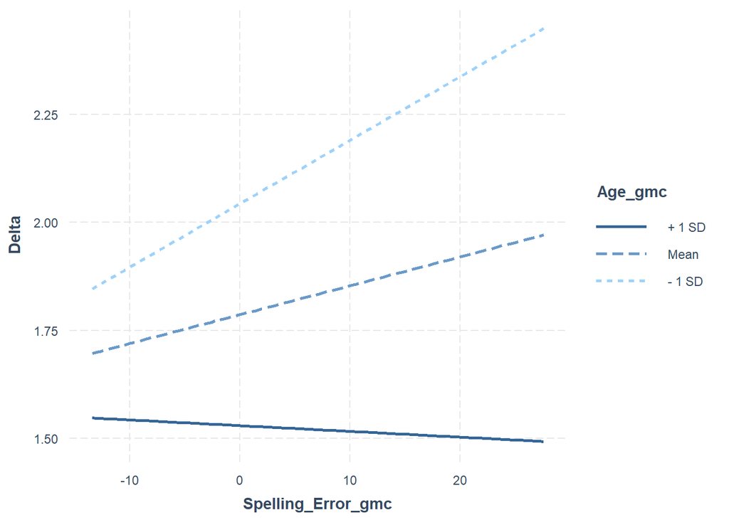

Table 1: Descriptive Statistics of Continuous Predictors

[output not shown]

### Visualizing the interaction on a 3D-plane (delta model only)

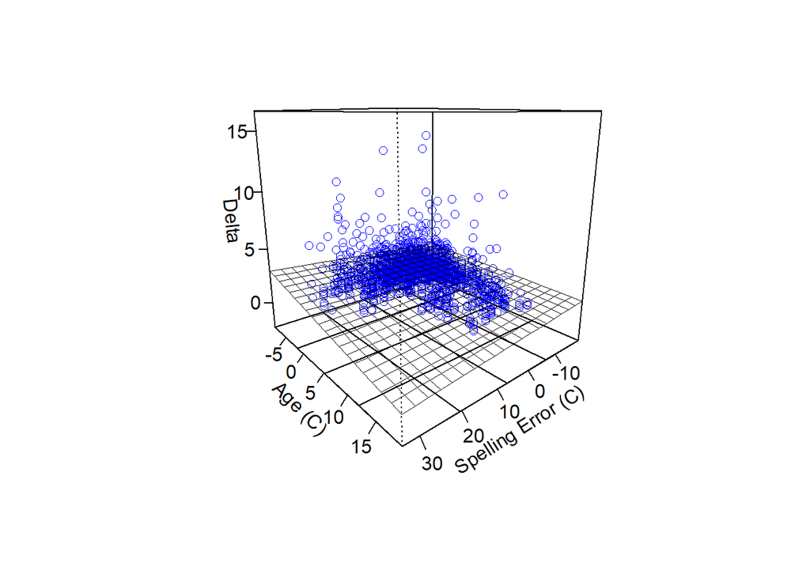

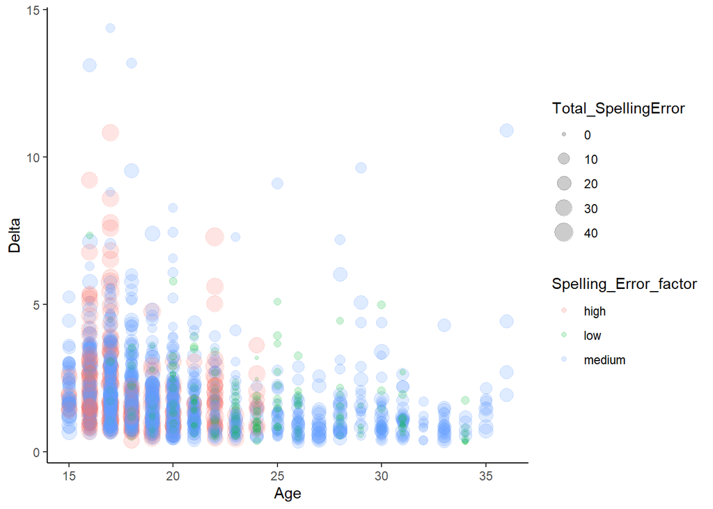

```
   vars    n  mean   sd median trimmed mad min max range skew kurtosis  se
X1    1 1796 13.38 8.61     12   12.59 8.9   0  41    41 0.74        0 0.2
```

## Post-estimation techniques

### Assumption 1: Linearity

We need to check if linearity is present by taking the residuals (Y - Y.hat) and plot it against every predictor in our model (I think this applies to continuous predictors) and to the fitted values. Then we will visually look for evidence of non linearity. To help with this, we can use locally weighted smooth (LOESS) lines on our scatterplots.

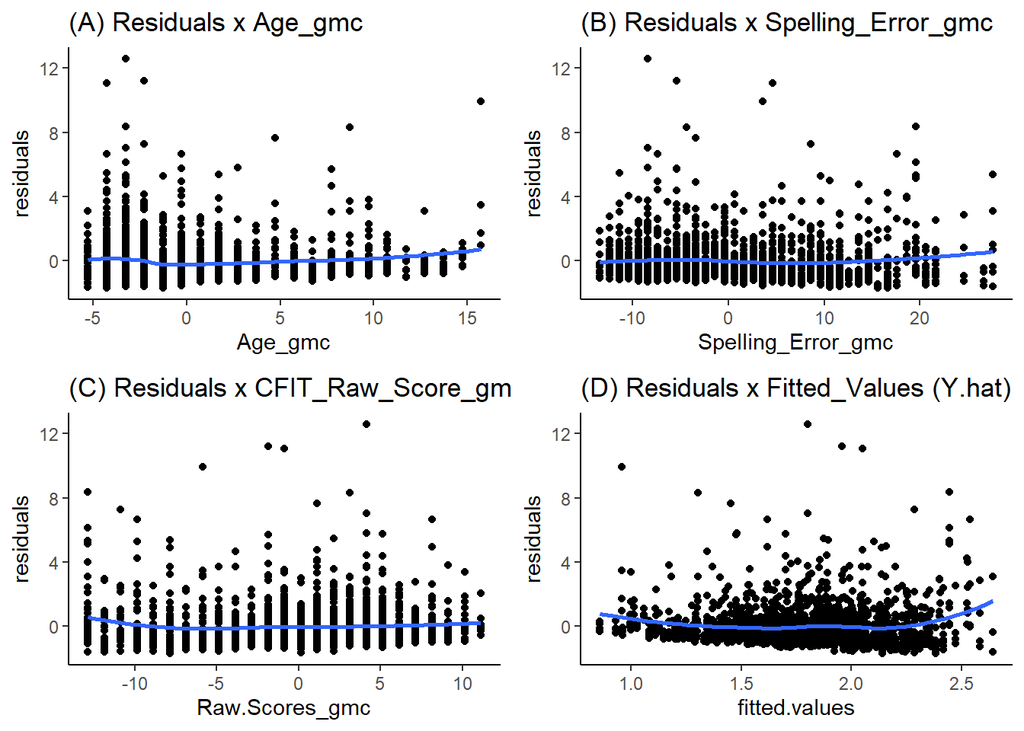

### Assumption 2: Homoscedasticity

Now wee need to look at the spread (variance) of residuals for different levels of predictors and fitted values, respectively. We can do this by looking at the same plots from above. Additionally, we can add two more lowess lines to our scatterplots, one that represents the mean + 1 sd and the other that represents the mean - 1 sd. If theses lines look to be horizontal then there is homoscedasticity. However, if we see the lines starting to converge on each other (in the examples from Cohen (2002) this seems to happen at the edges of the plots) then there is heteroscedasticity. The issue with this is that heteroscedasticity messes with the calculations of confidence intervals, which will make our results inaccurate.

UNFORTUNATELY, I was unable to find a package or anything helpful online to help create these lines. Instead, we will just graph boxplots and look at their spread and compare them for each quintile of the predictor.

The size of each box plot below shows to me that the assumption of homoscedasticity was not violated.

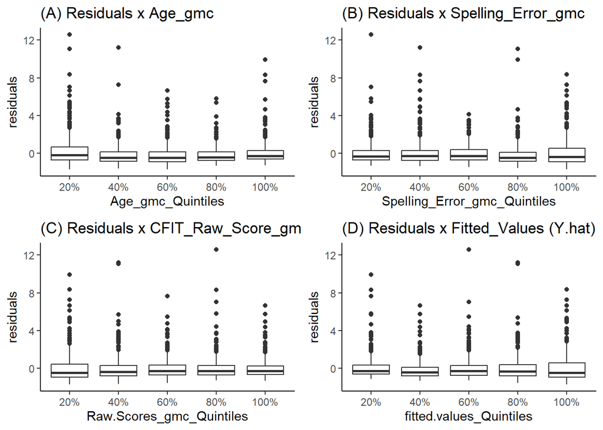

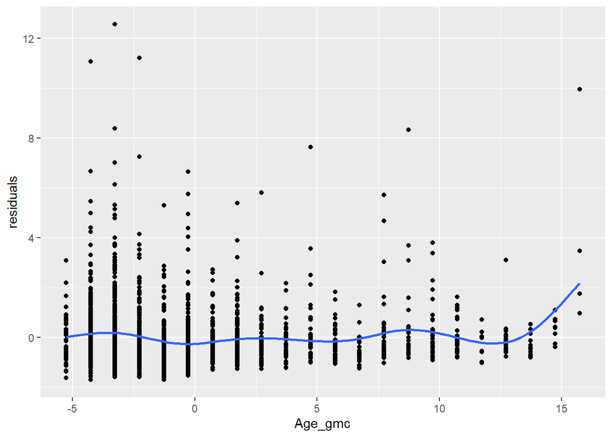

### Assumption 3: Normality of residuals

In continuation with Jacob Cohen and colleagues (2002) textbook, two different graphical methods can be used to investigate the normality of the residuals. The first (and least accurate) is to create a histogram of the residuals and to superimpose a normal curve over it. The issue with this graph is that it is sometimes difficult to tell whether the graph looks normally distributed or not- especially in smaller sample sizes. The second approach is to use a q-q plot, which shows if the residuals are normal if they create a straight diagonal line.

Both the histogram and q-q plot of residuals are saying the same thing. That the right rail of our distribution is long/heavy. Our graphs show clearly that the assumption of normality was violated.

A change was made below after reading more about outliers from Discovering Statistics Using R. While Cohen made a great point of graphing our residuals, the one major drawback is that these residuals are in the units of our outcome variable, which is delta power. It would be much more informative instead if we graph standardized residuals- that way we can see exactly how far they are away from the mean (0) in a standardized way (Aka if they are near 3 then we know these are problematic). The reason why standardized residuals larger than 3 are problematic is because they should be extremely rare in the data, for example, around 1 observation per 1,000 cases!

We will insert lines showing the standardized residuals that are very likely to be problematic.

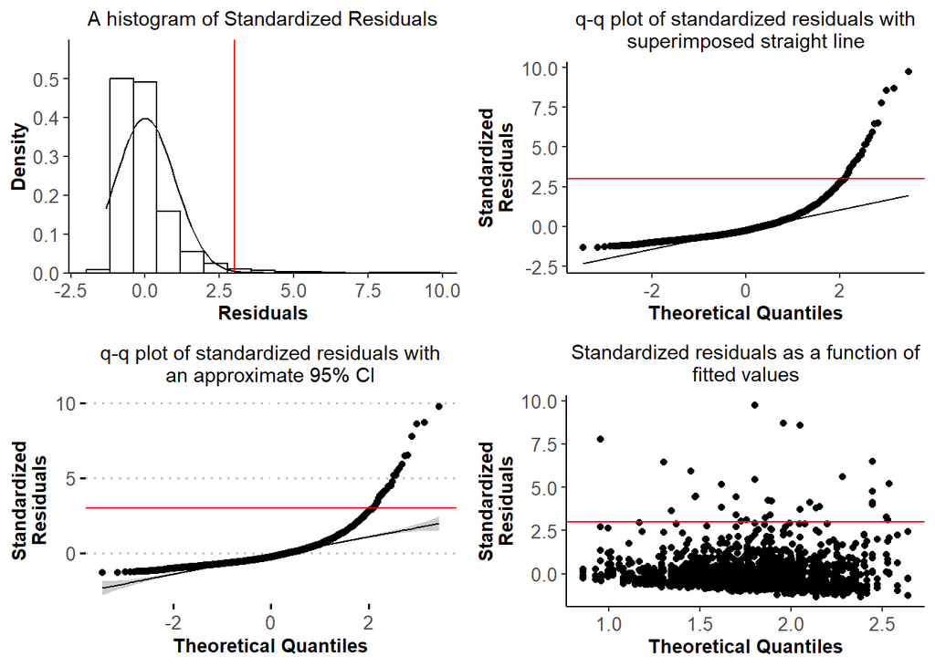

## Remedies: Alternative approaches when problems are detected

Jacob Cohen (2002) mentions remedies to help with all possible assumption violations in OLS regression EXCEPT FOR NORMALITY! So we will be switching to a different textbook to help. This next portion will be reporting on topics mentioned in Andy Field and Jeremy Miles (2012) Discovering Statistics Using R.

### Background information on outliers

Outliers can be defined as datapoints that are poorly predicted by the model when many other data points are predicted just fine. We can investigate if outliers are present by the same logic mentioned. If many data points are predicted well by the model, then we would except the difference between the observed value the the fitted value to be small. This is difference is called a residual. If we obtain the residuals for all of our data points, we can then standardized them to get an idea of just how far they are away from the fitted value in comparison to the other residuals. If they are too far away than would be expected, for example if they were 4 standard deviations away from the mean, then this would be a major reason for concern.

Now, there is a mathematical way to detect if we have the appropriate frequency/percentage of residual sizes in our data. For example, if we have 100 outcome scores, then we would expect 5 of them to be larger than 1.96 or smaller than -1.96. The same math can be done for larger/smaller residuals. Below we will be using a function to output exactly the frequency and percentage that would be expected for our data.

| standard.deviation | percentage | frequency | sample.size |
| --- | --- | --- | --- |
| 1.96 | 5.0 | 90 | 1796 |
| 2.58 | 1.0 | 18 | 1796 |
| 3.29 | 0.1 | 2 | 1796 |

### Comparing our errors to the acceptable level of error from our sample size

Below we can compare the table from above to a table created from our data. Looking at the standardized residuals alone, we can see that the total number of residuals that are more than 1.96 sd away from the mean is acceptable. However, this no longer becomes the case for residuals that are farther than 2.58 sd away from the mean.

| Expected Residual Numbers standard.deviation | Expected Residual Numbers percentage | Expected Residual Numbers frequency | Expected Residual Numbers sample.size | Obtained Residual Numbers standard.deviation | Obtained Residual Numbers percentage | Obtained Residual Numbers frequency | Obtained Residual Numbers sample.size |
| --- | --- | --- | --- | --- | --- | --- | --- |
| 1.96 | 5.0 | 90 | 1796 | 1.96 | 4.2 | 75 | 1796 |
| 2.58 | 1.0 | 18 | 1796 | 2.58 | 2.6 | 46 | 1796 |
| 3.29 | 0.1 | 2 | 1796 | 3.29 | 1.6 | 28 | 1796 |

### Background information on influential cases

There are several other tests aside from the size of the residuals that we can use to further investigate if our residual is an outlier or not. We will be covering three of them which are cooks distance, leverage, and covariance ratio.

Cooks distance is the overall influence a case has on the model and if the value is at a distance greater than 1 then that’s a problem.

The average leverage (hat values) can be calculated by adding 1 to your total number of predictors and then dividing by your sample size aka (k+1)/n. These values are between 0 and 1. There is no agreed upon consensus on when this is problematic but typically values that are 2 or 3 times bigger than the average leverage are problematic.

The covariance ratios are not well explained but important nonetheless. We need to identify cases where the values are outside the following boundaries. On further inspection- this just seems to be another way of expressing leverage… I think. - CVR > 1 + [3(k + 1)/n] - CVR < 1 - [3(k + 1)/n]

We will only be investigating these values in the residuals that are considered large, we will define large by being more than 2 standard deviations away from the mean.

It seems that from these three types of casewise diagnostics, the most important one is cooks distance. Since, there are no instances where a value for cook’s distance is greater than 1, then all of these should be okay?

On further reading, the non normal distribution of errors is in fact related to having extreme residuals in the model. This means that some people in our data have much much higher delta power than would be expected! This is problematic because since the assumption of normality seems to be violated, then that means we cannot generalize our results beyond our sample.

Table showing all data where residuals are farther than 1.96 sd from the mean

| ID | Sex | Age | Group | Raw.Scores | Total_SpellingError | Condition | Topography | Delta | Delta.z | rstandard | cooks.distance | leverage | covariance.ratios | outside.covariance.ratios |
| --- | --- | --- | --- | --- | --- | --- | --- | --- | --- | --- | --- | --- | --- | --- |
| 69338 | F | 17 | IC | 35 | 5 | Closed | occipital | 14.3675 | 9.4626 | 9.754235 | 0.0606 | 0.0044 | 0.6878 | 0.6878 < 0.9883 |
| 11058 | F | 18 | BF | 29 | 8 | Closed | frontal | 13.1775 | 8.5665 | 8.700450 | 0.0265 | 0.0024 | 0.7436 | 0.7436 < 0.9883 |
| 37582 | M | 16 | IC | 30 | 18 | Closed | occipital | 13.1148 | 8.5193 | 8.580223 | 0.0255 | 0.0024 | 0.7499 | 0.7499 < 0.9883 |
| 65330 | F | 36 | IC | 25 | 17 | Closed | frontal | 10.9074 | 6.8572 | 7.761678 | 0.1252 | 0.0143 | 0.8014 | 0.8014 < 0.9883 |
| 32300 | M | 17 | IC | 18 | 33 | Closed | frontal | 10.8249 | 6.7951 | 6.508705 | 0.0370 | 0.0061 | 0.8541 | 0.8541 < 0.9883 |
| 45965 | F | 29 | BF | 34 | 9 | Closed | frontal | 9.6367 | 5.9004 | 6.465286 | 0.0224 | 0.0037 | 0.8540 | 0.854 < 0.9883 |
| 27603 | M | 25 | BF | 32 | 10 | Closed | frontal | 9.0964 | 5.4935 | 5.926924 | 0.0117 | 0.0023 | 0.8758 | 0.8758 < 0.9883 |
| 31869 | F | 18 | IC | 20 | 22 | Closed | frontal | 9.5377 | 5.8258 | 5.627611 | 0.0162 | 0.0036 | 0.8891 | 0.8891 < 0.9883 |
| 69338 | F | 17 | IC | 35 | 5 | Closed | frontal | 8.8154 | 5.2819 | 5.444887 | 0.0189 | 0.0044 | 0.8971 | 0.8971 < 0.9883 |
| 57724 | F | 16 | IC | 21 | 31 | Closed | frontal | 9.2135 | 5.5817 | 5.187839 | 0.0262 | 0.0068 | 0.9090 | 0.909 < 0.9883 |
| 14385 | F | 20 | BF | 39 | 6 | Closed | frontal | 8.2753 | 4.8752 | 5.162062 | 0.0086 | 0.0023 | 0.9059 | 0.9059 < 0.9883 |
| 28723 | M | 17 | IC | 18 | 33 | Closed | frontal | 8.5889 | 5.1114 | 4.771751 | 0.0199 | 0.0061 | 0.9234 | 0.9234 < 0.9883 |
| 49718 | M | 23 | BF | 35 | 5 | Closed | frontal | 7.2857 | 4.1301 | 4.503158 | 0.0073 | 0.0025 | 0.9292 | 0.9292 < 0.9883 |
| 98181 | F | 20 | BF | 36 | 8 | Closed | occipital | 7.4530 | 4.2561 | 4.458741 | 0.0047 | 0.0016 | 0.9299 | 0.9299 < 0.9883 |
| 73797 | F | 28 | BF | 29 | 8 | Closed | frontal | 7.1875 | 4.0561 | 4.431630 | 0.0103 | 0.0037 | 0.9327 | 0.9327 < 0.9883 |
| 63843 | F | 16 | BF | 33 | 2 | Closed | frontal | 7.3358 | 4.1678 | 4.237313 | 0.0101 | 0.0039 | 0.9392 | 0.9392 < 0.9883 |
| 53753 | M | 22 | IC | 23 | 41 | Closed | frontal | 7.2773 | 4.1238 | 4.190675 | 0.0260 | 0.0103 | 0.9467 | 0.9467 < 0.9883 |
| 28723 | M | 17 | IC | 18 | 33 | Closed | occipital | 7.7666 | 4.4922 | 4.132942 | 0.0149 | 0.0061 | 0.9445 | 0.9445 < 0.9883 |
| 28735 | M | 19 | IC | 21 | 23 | Closed | frontal | 7.4091 | 4.2230 | 4.117001 | 0.0075 | 0.0031 | 0.9421 | 0.9421 < 0.9883 |
| 32300 | M | 17 | IC | 18 | 33 | Closed | occipital | 7.5915 | 4.3603 | 3.996942 | 0.0140 | 0.0061 | 0.9486 | 0.9486 < 0.9883 |
| 58571 | M | 16 | IC | 29 | 24 | Closed | occipital | 7.1389 | 4.0195 | 3.863150 | 0.0065 | 0.0030 | 0.9496 | 0.9496 < 0.9883 |
| 14385 | F | 20 | BF | 39 | 6 | Closed | occipital | 6.5629 | 3.5858 | 3.834340 | 0.0048 | 0.0023 | 0.9497 | 0.9497 < 0.9883 |
| 75267 | F | 17 | IC | 23 | 10 | Closed | occipital | 7.0488 | 3.9517 | 3.811904 | 0.0094 | 0.0045 | 0.9525 | 0.9525 < 0.9883 |
| 80899 | M | 17 | IC | 32 | 27 | Closed | occipital | 6.8363 | 3.7917 | 3.714338 | 0.0083 | 0.0042 | 0.9550 | 0.955 < 0.9883 |
| 12534 | M | 28 | BF | 27 | 19 | Closed | frontal | 6.0247 | 3.1806 | 3.635800 | 0.0130 | 0.0068 | 0.9597 | 0.9597 < 0.9883 |
| 16988 | F | 16 | BF | 35 | 6 | Closed | frontal | 6.2960 | 3.3848 | 3.419156 | 0.0045 | 0.0027 | 0.9615 | 0.9615 < 0.9883 |
| 98181 | F | 20 | BF | 36 | 8 | Closed | temporal | 6.0847 | 3.2257 | 3.398193 | 0.0027 | 0.0016 | 0.9610 | 0.961 < 0.9883 |
| 55335 | F | 16 | IC | 21 | 30 | Closed | frontal | 6.7608 | 3.7348 | 3.292243 | 0.0098 | 0.0063 | 0.9682 | 0.9682 < 0.9883 |
| 83415 | M | 18 | BF | 32 | 14 | Closed | frontal | 6.0130 | 3.1717 | 3.222164 | 0.0036 | 0.0024 | 0.9662 | 0.9662 < 0.9883 |
| 44473 | F | 20 | BF | 32 | 3 | Closed | frontal | 5.7974 | 3.0094 | 3.132795 | 0.0027 | 0.0019 | 0.9679 | 0.9679 < 0.9883 |
| 74339 | F | 17 | IC | 18 | 32 | Closed | occipital | 6.5253 | 3.5575 | 3.105445 | 0.0094 | 0.0068 | 0.9732 | 0.9732 < 0.9883 |
| 53714 | M | 22 | IC | 29 | 32 | Closed | occipital | 5.6164 | 2.8731 | 3.022999 | 0.0079 | 0.0060 | 0.9744 | 0.9744 < 0.9883 |
| 40428 | F | 30 | BF | 40 | 4 | Closed | frontal | 4.9770 | 2.3916 | 2.959881 | 0.0107 | 0.0084 | 0.9783 | 0.9783 < 0.9883 |
| 80707 | F | 17 | BF | 35 | 18 | Closed | occipital | 5.7610 | 2.9820 | 2.923544 | 0.0048 | 0.0039 | 0.9746 | 0.9746 < 0.9883 |
| 69338 | F | 17 | IC | 35 | 5 | Closed | parietal | 5.5599 | 2.8306 | 2.918143 | 0.0054 | 0.0044 | 0.9753 | 0.9753 < 0.9883 |
| 56172 | M | 17 | IC | 26 | 28 | Closed | parietal | 5.9355 | 3.1134 | 2.897402 | 0.0038 | 0.0032 | 0.9745 | 0.9745 < 0.9883 |
| 12573 | M | 18 | BF | 27 | 21 | Closed | frontal | 5.7795 | 2.9959 | 2.895936 | 0.0045 | 0.0038 | 0.9751 | 0.9751 < 0.9883 |
| 35817 | M | 29 | BF | 23 | 19 | Closed | frontal | 5.0667 | 2.4592 | 2.876466 | 0.0109 | 0.0092 | 0.9809 | 0.9809 < 0.9883 |
| 43831 | M | 16 | IC | 32 | 23 | Closed | occipital | 5.7799 | 2.9962 | 2.874096 | 0.0041 | 0.0035 | 0.9753 | 0.9753 < 0.9883 |
| 72605 | F | 17 | BF | 35 | 7 | Closed | frontal | 5.5208 | 2.8011 | 2.841978 | 0.0025 | 0.0021 | 0.9747 | 0.9747 < 0.9883 |
| 29847 | F | 25 | BF | 33 | 2 | Closed | occipital | 5.0948 | 2.4804 | 2.757930 | 0.0037 | 0.0034 | 0.9777 | 0.9777 < 0.9883 |
| 98181 | F | 20 | BF | 36 | 8 | Closed | frontal | 5.2197 | 2.5744 | 2.727790 | 0.0017 | 0.0016 | 0.9767 | 0.9767 < 0.9883 |
| 37212 | F | 18 | IC | 30 | 14 | Closed | frontal | 5.4865 | 2.7753 | 2.726803 | 0.0021 | 0.0020 | 0.9770 | 0.977 < 0.9883 |
| 65330 | F | 36 | IC | 25 | 17 | Closed | occipital | 4.4304 | 1.9801 | 2.709215 | 0.0153 | 0.0143 | 0.9896 |  |
| 53036 | M | 30 | BF | 41 | 9 | Closed | temporal | 4.3868 | 1.9472 | 2.632638 | 0.0065 | 0.0065 | 0.9834 | 0.9834 < 0.9883 |
| 13465 | M | 17 | BF | 32 | 12 | Closed | occipital | 5.2402 | 2.5898 | 2.597129 | 0.0026 | 0.0027 | 0.9803 | 0.9803 < 0.9883 |
| 19995 | M | 18 | BF | 30 | 13 | Closed | occipital | 5.2134 | 2.5697 | 2.575340 | 0.0025 | 0.0026 | 0.9807 | 0.9807 < 0.9883 |
| 83619 | F | 16 | IC | 36 | 5 | Closed | frontal | 5.1203 | 2.4996 | 2.562280 | 0.0048 | 0.0050 | 0.9834 | 0.9834 < 0.9883 |
| 75267 | F | 17 | IC | 23 | 10 | Closed | frontal | 5.3614 | 2.6811 | 2.502141 | 0.0040 | 0.0045 | 0.9840 | 0.984 < 0.9883 |
| 86758 | M | 22 | IC | 25 | 30 | Closed | frontal | 5.0247 | 2.4276 | 2.495884 | 0.0040 | 0.0044 | 0.9841 | 0.9841 < 0.9883 |
| 11058 | F | 18 | BF | 29 | 8 | Closed | temporal | 5.1489 | 2.5211 | 2.475129 | 0.0021 | 0.0024 | 0.9825 | 0.9825 < 0.9883 |
| 55728 | F | 17 | IC | 18 | 41 | Closed | frontal | 5.7470 | 2.9715 | 2.418996 | 0.0101 | 0.0120 | 0.9930 |  |
| 50728 | F | 33 | IC | 25 | 15 | Closed | frontal | 4.2911 | 1.8752 | 2.417944 | 0.0075 | 0.0089 | 0.9900 |  |
| 21287 | F | 15 | IC | 29 | 13 | Closed | frontal | 5.2467 | 2.5947 | 2.399358 | 0.0021 | 0.0025 | 0.9840 | 0.984 < 0.9883 |
| 45965 | F | 29 | BF | 34 | 9 | Closed | temporal | 4.3851 | 1.9460 | 2.390613 | 0.0031 | 0.0037 | 0.9854 | 0.9854 < 0.9883 |
| 15696 | F | 28 | BF | 34 | 2 | Closed | frontal | 4.4387 | 1.9863 | 2.356895 | 0.0050 | 0.0063 | 0.9885 |  |
| 97251 | F | 17 | IC | 31 | 13 | Closed | occipital | 4.9993 | 2.4084 | 2.331262 | 0.0017 | 0.0022 | 0.9850 | 0.985 < 0.9883 |
| 99689 | M | 16 | IC | 19 | 25 | Closed | occipital | 5.3547 | 2.6761 | 2.292887 | 0.0038 | 0.0050 | 0.9884 |  |
| 69338 | F | 17 | IC | 35 | 5 | Closed | temporal | 4.7115 | 2.1917 | 2.259646 | 0.0033 | 0.0044 | 0.9884 |  |
| 99689 | M | 16 | IC | 19 | 25 | Closed | frontal | 5.3054 | 2.6389 | 2.254633 | 0.0036 | 0.0050 | 0.9891 |  |
| 80941 | F | 19 | IC | 29 | 17 | Closed | occipital | 4.8275 | 2.2791 | 2.222909 | 0.0013 | 0.0018 | 0.9865 | 0.9865 < 0.9883 |
| 57322 | F | 17 | IC | 19 | 38 | Closed | frontal | 5.4340 | 2.7358 | 2.219811 | 0.0069 | 0.0097 | 0.9943 |  |
| 42100 | F | 17 | BF | 35 | 8 | Closed | occipital | 4.6539 | 2.1484 | 2.160137 | 0.0014 | 0.0021 | 0.9878 | 0.9878 < 0.9883 |
| 32115 | F | 17 | BF | 38 | 1 | Closed | occipital | 4.4773 | 2.0154 | 2.146062 | 0.0022 | 0.0033 | 0.9893 |  |
| 53462 | M | 21 | IC | 33 | 20 | Closed | occipital | 4.3837 | 1.9449 | 2.112351 | 0.0019 | 0.0030 | 0.9895 |  |
| 67402 | F | 19 | BF | 32 | 13 | Closed | occipital | 4.5979 | 2.1062 | 2.103050 | 0.0012 | 0.0019 | 0.9885 |  |
| 80899 | M | 17 | IC | 32 | 27 | Closed | frontal | 4.7583 | 2.2270 | 2.101621 | 0.0027 | 0.0042 | 0.9908 |  |
| 47900 | M | 17 | BF | 31 | 10 | Closed | frontal | 4.5930 | 2.1025 | 2.097356 | 0.0019 | 0.0030 | 0.9898 |  |
| 74421 | M | 19 | IC | 31 | 13 | Closed | frontal | 4.4844 | 2.0207 | 2.095076 | 0.0017 | 0.0027 | 0.9895 |  |
| 57724 | F | 16 | IC | 21 | 31 | Closed | occipital | 5.1899 | 2.5520 | 2.061190 | 0.0041 | 0.0068 | 0.9941 |  |
| 14385 | F | 20 | BF | 39 | 6 | Closed | temporal | 4.2406 | 1.8371 | 2.033886 | 0.0013 | 0.0023 | 0.9900 |  |
| 59761 | M | 17 | IC | 33 | 6 | Closed | frontal | 4.3579 | 1.9255 | 2.014762 | 0.0031 | 0.0053 | 0.9933 |  |
| 79147 | M | 21 | BF | 37 | 8 | Closed | frontal | 4.1213 | 1.7473 | 2.006114 | 0.0013 | 0.0023 | 0.9905 |  |
| 74222 | M | 23 | BF | 33 | 10 | Closed | frontal | 4.1176 | 1.7445 | 2.003799 | 0.0011 | 0.0020 | 0.9902 |  |
| 76170 | F | 16 | IC | 22 | 28 | Closed | frontal | 5.0243 | 2.4273 | 1.982265 | 0.0029 | 0.0052 | 0.9937 |  |

### Remove the outliers?

```
Call:
lm(formula = Delta ~ Total_SpellingError * Age_gmc + Raw.Scores_gmc +
    Male + IC, data = data3)

Residuals:
    Min      1Q  Median      3Q     Max
-1.4108 -0.6281 -0.2221  0.3606  3.9882

Coefficients:
                              Estimate Std. Error t value Pr(>|t|)
(Intercept)                  1.6315114  0.0500120  32.622  < 2e-16 ***
Total_SpellingError          0.0015466  0.0037324   0.414   0.6787
Age_gmc                     -0.0391207  0.0096930  -4.036 5.68e-05 ***
Raw.Scores_gmc              -0.0125943  0.0053272  -2.364   0.0182 *
Male                        -0.0332078  0.0462583  -0.718   0.4729
IC                          -0.0331838  0.0562876  -0.590   0.5556
Total_SpellingError:Age_gmc -0.0016347  0.0006807  -2.402   0.0164 *
---
Signif. codes:  0 '***' 0.001 '**' 0.01 '*' 0.05 '.' 0.1 ' ' 1

Residual standard error: 0.8949 on 1681 degrees of freedom
Multiple R-squared:  0.08867,   Adjusted R-squared:  0.08542
F-statistic: 27.26 on 6 and 1681 DF,  p-value: < 2.2e-16
```

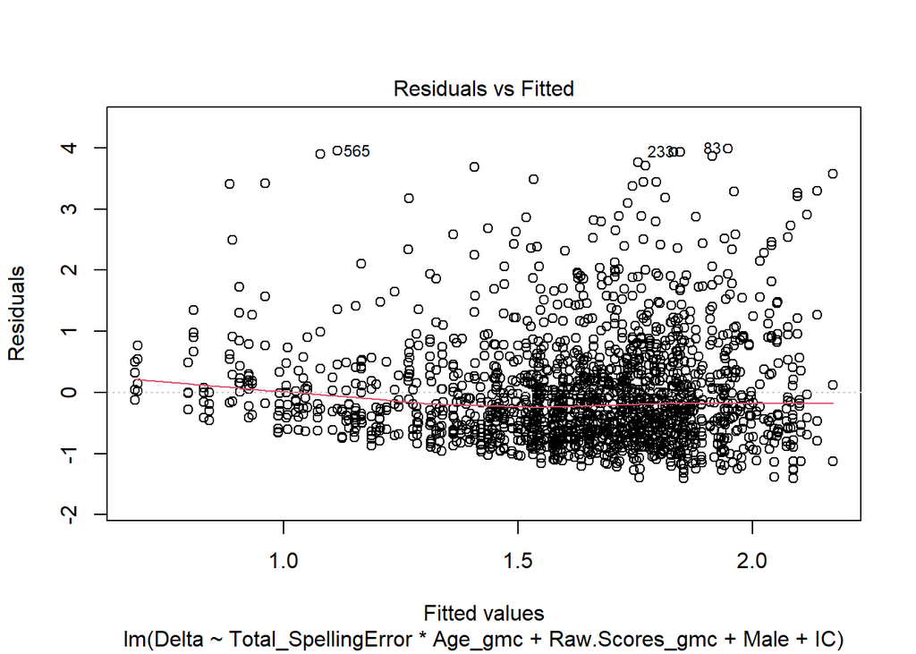

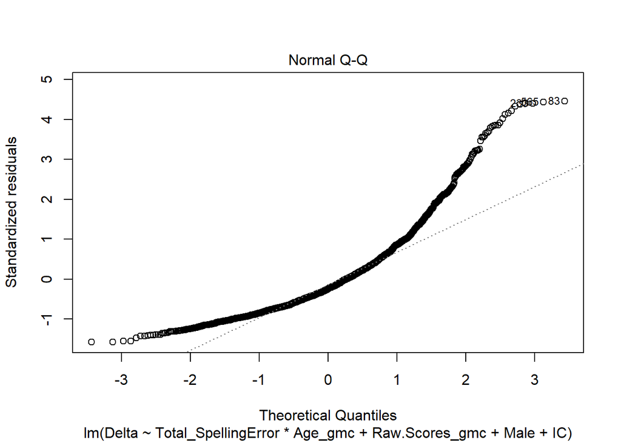

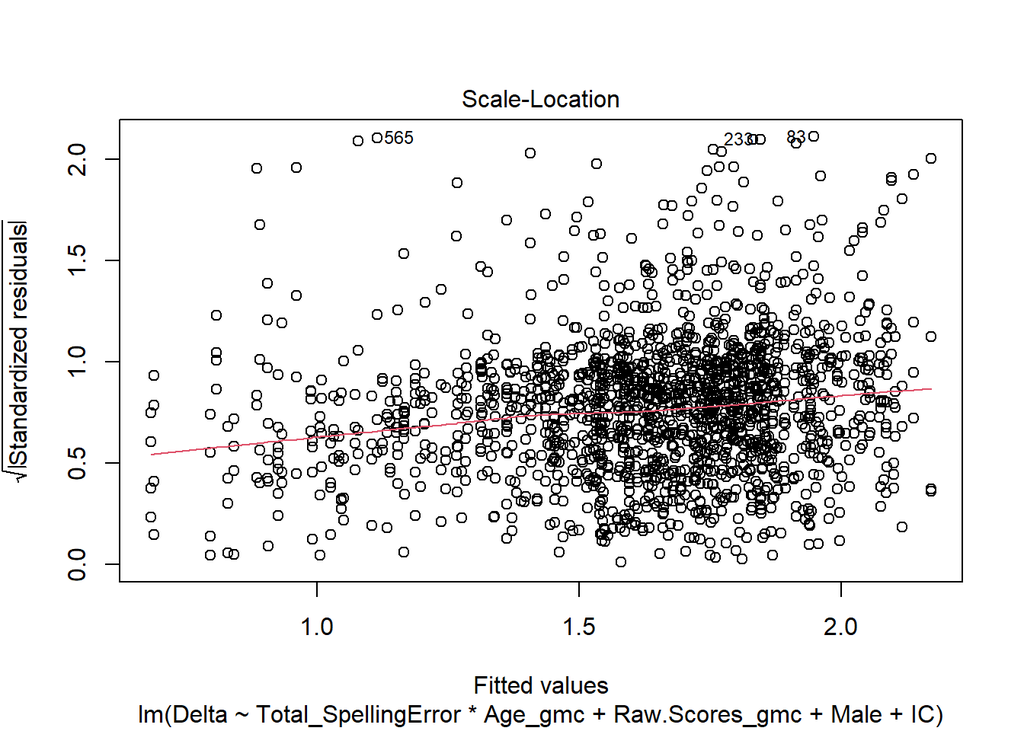

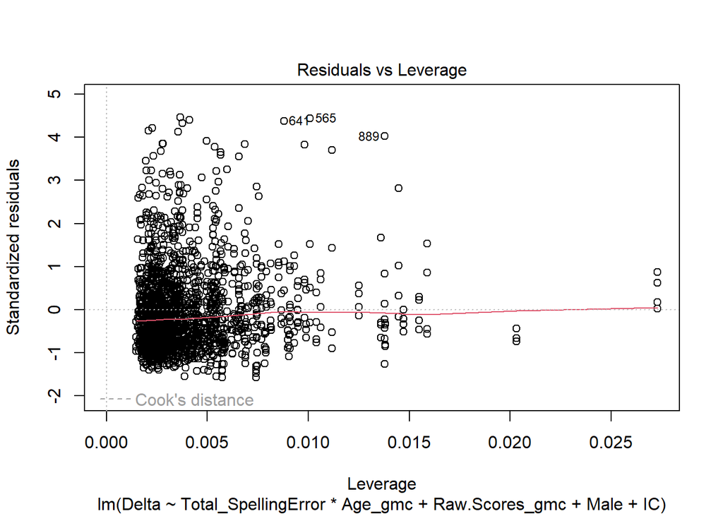